# optiver

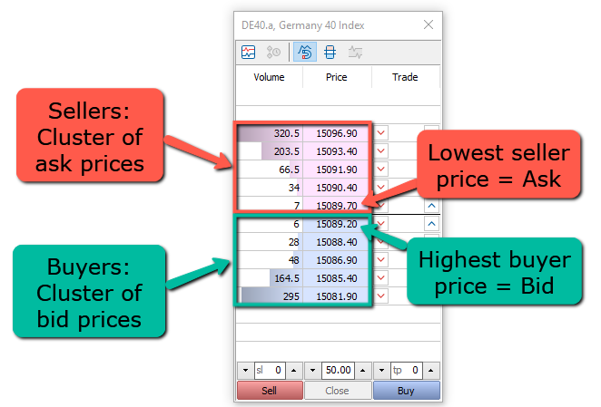

```
trainging : date_id 0~480 (2021-08-03to2023-06-30)
```

Public Learderboard: -from training (Unscored): date_id:478-480 -Scored: date_id: 481-525 -Unscored: date_id: 526-560 (seven weeks interim data added at last time) -Unscored: date_id: 561-582 (one month interim data added this time)

Fututre Unsocred: date_id；583-596 （14 weekdays from Dec 1st to Dec 20th ）

Pivate LeaderBoard: Unscored: date_id: 478 to ~ 596 Scored: date_id: 597 to ~ 597+10* (Dec 20th to Mar 20th, and the LB will update ever 2 weeks)**

https://stackoverflow.com/questions/77154545/which-pandas-methods-have-engine-kwargs-for-numba-support

Here is an (hopefully) exhaustive list of pandas function that support engine="numba".

Top level pandas functions:

pandas.eval Groupby operations (DataFrame and Series):

pandas.core.groupby.DataFrameGroupBy.mean, sum, median, var, std, min, max agg transform apply Rolling operations:

pandas.core.window.rolling.Rolling.mean, sum, median, var, std , min , max

apply

Expanding operations

pandas.core.window.expanding.Expanding.mean, sum, median, var, std, min, max apply Exponential moving window (ewm) operations:

pandas.core.window.ewm.ExponentialMovingWindow.mean, sum, var, std, min, max apply

Bid_Ask_Spread = (Ask_Price - Bid_Price ) / Ask_Price

```python
import numpy as np
import pandas as pd
from tqdm.notebook import tqdm
from datetime import date, datetime
from numba import jit
import numba
from numba.extending import overload
from math import fabs
import polars as pl

import matplotlib.pyplot as plt
%matplotlib inline
import plotly.figure_factory as ff
import plotly.graph_objects as go
import plotly.express as px
from plotly.subplots import make_subplots
import plotly.io as pio
pio.renderers.default = 'notebook'
import seaborn as sns

from sklearn.decomposition import PCA
from sklearn.preprocessing import LabelEncoder, StandardScaler  # z = (x - u) / s
from sklearn.ensemble import HistGradientBoostingRegressor
from sklearn.linear_model import LinearRegression
from sklearn.metrics import r2_score
from sklearn.model_selection import TimeSeriesSplit
from sklearn.cluster import MeanShift, estimate_bandwidth
from tqdm import tqdm

from sklearn.metrics import mean_absolute_error
from sklearn.model_selection import cross_val_score, GridSearchCV

import lightgbm as lgb

from joblib import dump, load
import pickle
from IPython.display import display, HTML
display(HTML("<style>.container { width:100% !important; }</style>"))
pio.renderers.default = 'notebook'

sns.set_context("notebook")
```

```python
%%time
import polars as pl
pldf = pl.read_csv("train.csv", # /kaggle/input/optiver-trading-at-the-close/
                    dtypes={
                         'stock_id': pl.Int16,
                         'date_id': pl.Int16,
                         'seconds_in_bucket': pl.Int16,
                         'imbalance_size': pl.Float32,
                         'imbalance_buy_sell_flag': pl.Int8,
                         'reference_price': pl.Float32,
                         'matched_size': pl.Float32,
                         'far_price': pl.Float32,
                         'near_price': pl.Float32,
                         'bid_price': pl.Float32,
                         'bid_size': pl.Float32,
                         'ask_price': pl.Float32,
                         'ask_size': pl.Float32,
                         'wap': pl.Float32,
                         'target': pl.Float32,
                         'time_id': pl.Int16,
                         'row_id': pl.Utf8
                    })
pldf
```

```
CPU times: user 3.23 s, sys: 808 ms, total: 4.04 s
Wall time: 16.3 s
```

shape: (5_237_980, 17)

| stock_id i16 | date_id i16 | seconds_in_bucket i16 | imbalance_size f32 | imbalance_buy_sell_flag i8 | reference_price f32 | matched_size f32 | far_price f32 | near_price f32 | bid_price f32 | bid_size f32 | ask_price f32 | ask_size f32 | wap f32 | target f32 | time_id i16 | row_id str |
| --- | --- | --- | --- | --- | --- | --- | --- | --- | --- | --- | --- | --- | --- | --- | --- | --- |
| 0 | 0 | 0 | 3.1806e6 | 1 | 0.999812 | 1.3380277e7 | null | null | 0.999812 | 60651.5 | 1.000026 | 8493.030273 | 1.0 | -3.029704 | 0 | "0_0_0" |
| 1 | 0 | 0 | 166603.90625 | -1 | 0.999896 | 1.6422e6 | null | null | 0.999896 | 3233.040039 | 1.00066 | 20605.089844 | 1.0 | -5.519986 | 0 | "0_0_1" |
| 2 | 0 | 0 | 302879.875 | -1 | 0.999561 | 1.819368e6 | null | null | 0.999403 | 37956.0 | 1.000298 | 18995.0 | 1.0 | -8.38995 | 0 | "0_0_2" |
| 3 | 0 | 0 | 1.1917682e7 | -1 | 1.000171 | 1.8389746e7 | null | null | 0.999999 | 2324.899902 | 1.000214 | 479032.40625 | 1.0 | -4.010201 | 0 | "0_0_3" |
| 4 | 0 | 0 | 447549.96875 | -1 | 0.999532 | 1.7860614e7 | null | null | 0.999394 | 16485.539062 | 1.000016 | 434.100006 | 1.0 | -7.349849 | 0 | "0_0_4" |
| 5 | 0 | 0 | 0.0 | 0 | 1.000635 | 1.3552876e7 | null | null | 0.999779 | 1962.719971 | 1.000635 | 5647.649902 | 1.0 | 6.779432 | 0 | "0_0_5" |
| 6 | 0 | 0 | 969969.375 | 1 | 1.000115 | 3.647504e6 | null | null | 0.999506 | 6663.160156 | 1.000283 | 3810.47998 | 1.0 | -2.499819 | 0 | "0_0_6" |
| 7 | 0 | 0 | 9.412959e6 | 1 | 0.999818 | 2.1261246e7 | null | null | 0.999741 | 5139.200195 | 1.00013 | 2570.600098 | 1.0 | -1.959801 | 0 | "0_0_7" |
| 8 | 0 | 0 | 2.3949e6 | 1 | 0.999916 | 9.473209e6 | null | null | 0.999022 | 52011.601562 | 1.000041 | 2169.360107 | 1.0 | -5.970001 | 0 | "0_0_8" |
| 9 | 0 | 0 | 3.0397e6 | -1 | 1.000969 | 6248958.5 | null | null | 0.999354 | 6191.0 | 1.000646 | 6199.0 | 1.0 | 7.970333 | 0 | "0_0_9" |
| 10 | 0 | 0 | 1.0482752e7 | -1 | 1.001374 | 8.839457e6 | null | null | 0.999885 | 18802.0 | 1.001321 | 217098.375 | 1.0 | 5.350113 | 0 | "0_0_10" |
| 11 | 0 | 0 | 1.5061e6 | -1 | 0.999968 | 2001112.5 | null | null | 0.99984 | 1174.449951 | 1.000351 | 2585.110107 | 1.0 | 2.559423 | 0 | "0_0_11" |
| … | … | … | … | … | … | … | … | … | … | … | … | … | … | … | … | … |
| 188 | 480 | 540 | 18930.380859 | -1 | 0.999741 | 6465049.5 | 0.999741 | 0.999741 | 0.999741 | 117186.859375 | 1.000297 | 217260.0 | 0.999936 | -0.699759 | 26454 | "480_540_188" |
| 189 | 480 | 540 | 956757.9375 | 1 | 1.000715 | 3.7109376e7 | 1.001167 | 1.001054 | 1.000602 | 788361.125 | 1.000715 | 49599.199219 | 1.000708 | 6.959438 | 26454 | "480_540_189" |
| 190 | 480 | 540 | 466320.15625 | -1 | 0.999295 | 3.9294716e7 | 0.998983 | 0.999139 | 0.999295 | 19725.859375 | 0.999451 | 169105.203125 | 0.999311 | -0.470281 | 26454 | "480_540_190" |
| 191 | 480 | 540 | 3.6937784e7 | 1 | 0.995983 | 6.08326144e8 | 0.999086 | 0.997746 | 0.995913 | 84744.0 | 0.995983 | 48025.0 | 0.995958 | 0.799894 | 26454 | "480_540_191" |
| 192 | 480 | 540 | 67162.617188 | 1 | 1.000762 | 1.1790079e7 | 1.000834 | 1.000762 | 1.000545 | 168412.859375 | 1.000762 | 69841.5 | 1.000698 | -1.729727 | 26454 | "480_540_192" |
| 193 | 480 | 540 | 6.500948e6 | 1 | 1.001599 | 8.0357528e7 | 1.002908 | 1.002326 | 1.001454 | 413142.25 | 1.001599 | 363532.53125 | 1.001531 | -3.880262 | 26454 | "480_540_193" |
| 194 | 480 | 540 | 262271.53125 | -1 | 1.001504 | 3922295.5 | 1.000677 | 1.000677 | 1.001504 | 20829.199219 | 1.001917 | 139637.484375 | 1.001557 | 4.839897 | 26454 | "480_540_194" |
| 195 | 480 | 540 | 2.440723e6 | -1 | 1.000317 | 2.8280362e7 | 0.999734 | 0.999734 | 1.000317 | 32257.039062 | 1.000434 | 319862.40625 | 1.000328 | 2.310276 | 26454 | "480_540_195" |
| 196 | 480 | 540 | 349510.46875 | -1 | 1.000643 | 9.187699e6 | 1.000129 | 1.000386 | 1.000643 | 205108.40625 | 1.0009 | 93393.070312 | 1.000819 | -8.220077 | 26454 | "480_540_196" |
| 197 | 480 | 540 | 0.0 | 0 | 0.995789 | 1.2725436e7 | 0.995789 | 0.995789 | 0.995789 | 16790.660156 | 0.995883 | 180038.3125 | 0.995797 | 1.169443 | 26454 | "480_540_197" |
| 198 | 480 | 540 | 1.0009e6 | 1 | 0.99921 | 9.4773272e7 | 0.99921 | 0.99921 | 0.99897 | 125631.71875 | 0.99921 | 669893.0 | 0.999008 | -1.540184 | 26454 | "480_540_198" |
| 199 | 480 | 540 | 1.8843e6 | -1 | 1.002129 | 2.4073678e7 | 1.000859 | 1.001494 | 1.002129 | 250081.4375 | 1.002447 | 300167.5625 | 1.002274 | -6.530285 | 26454 | "480_540_199" |

```python
%%time
# The train auction data.
df = pd.read_csv('train.csv').sort_values(['stock_id','date_id'],ascending=[True, True])
print('Size of the raw dataset : ', df.shape)
print(f'Total days count: {df.date_id.nunique()}')
print(f'Total stocks count: {df.stock_id.nunique()}')
print(f'Total second bucket count: {df.seconds_in_bucket.nunique()}')
# Check any NaN, inf
print("-"*15,"train.csv Check any NaN, inf ","-"*15)
print(df.isin([np.inf, -np.inf, np.nan]).sum())
print(df.info(5))
```

```
Size of the raw dataset :  (5237980, 17)
Total days count: 481
Total stocks count: 200
Total second bucket count: 55
--------------- train.csv Check any NaN, inf  ---------------
stock_id                         0
date_id                          0
seconds_in_bucket                0
imbalance_size                 220
imbalance_buy_sell_flag          0
reference_price                220
matched_size                   220
far_price                  2894342
near_price                 2857180
bid_price                      220
bid_size                         0
ask_price                      220
ask_size                         0
wap                            220
target                          88
time_id                          0
row_id                           0
dtype: int64
<class 'pandas.core.frame.DataFrame'>
Index: 5237980 entries, 0 to 5237979
Data columns (total 17 columns):
 #   Column                   Dtype
---  ------                   -----
 0   stock_id                 int64
 1   date_id                  int64
 2   seconds_in_bucket        int64
 3   imbalance_size           float64
 4   imbalance_buy_sell_flag  int64
 5   reference_price          float64
 6   matched_size             float64
 7   far_price                float64
 8   near_price               float64
 9   bid_price                float64
 10  bid_size                 float64
 11  ask_price                float64
 12  ask_size                 float64
 13  wap                      float64
 14  target                   float64
 15  time_id                  int64
 16  row_id                   object
dtypes: float64(11), int64(5), object(1)
memory usage: 719.3+ MB
None
CPU times: user 15.8 s, sys: 2.7 s, total: 18.5 s
Wall time: 26.1 s
```

```python
%%time
def inspect_columns(df):
    # A helper function that does a better job than df.info() and df.describe()
    result = pd.DataFrame({
        'unique': df.nunique() == len(df),
        'cardinality': df.nunique(),
        'with_null': df.isna().any(),
        'null_pct': round((df.isnull().sum() / len(df)) * 100, 2),
        '1st_row': df.iloc[0],
        'random_row': df.iloc[np.random.randint(low=0, high=len(df))],
        'last_row': df.iloc[-1],
        'dtype': df.dtypes
    })
    return result

inspect_columns(df)
```

```
CPU times: user 10.8 s, sys: 942 ms, total: 11.7 s
Wall time: 11.9 s
```

|  | unique | cardinality | with_null | null_pct | 1st_row | random_row | last_row | dtype |
| --- | --- | --- | --- | --- | --- | --- | --- | --- |
| stock_id | False | 200 | False | 0.00 | 0 | 194 | 199 | int64 |
| date_id | False | 481 | False | 0.00 | 0 | 3 | 480 | int64 |
| seconds_in_bucket | False | 55 | False | 0.00 | 0 | 10 | 540 | int64 |
| imbalance_size | False | 2971863 | True | 0.00 | 3180602.69 | 0.0 | 1884285.71 | float64 |
| imbalance_buy_sell_flag | False | 3 | False | 0.00 | 1 | 0 | -1 | int64 |
| reference_price | False | 28741 | True | 0.00 | 0.999812 | 0.999969 | 1.002129 | float64 |
| matched_size | False | 2948862 | True | 0.00 | 13380276.64 | 4098859.08 | 24073677.32 | float64 |
| far_price | False | 95739 | True | 55.26 | NaN | NaN | 1.000859 | float64 |
| near_price | False | 84625 | True | 54.55 | NaN | NaN | 1.001494 | float64 |
| bid_price | False | 28313 | True | 0.00 | 0.999812 | 0.999969 | 1.002129 | float64 |
| bid_size | False | 2591773 | False | 0.00 | 60651.5 | 7202.0 | 250081.44 | float64 |
| ask_price | False | 28266 | True | 0.00 | 1.000026 | 1.000385 | 1.002447 | float64 |
| ask_size | False | 2623254 | False | 0.00 | 8493.03 | 14410.0 | 300167.56 | float64 |
| wap | False | 31506 | True | 0.00 | 1.0 | 1.000107 | 1.002274 | float64 |
| target | False | 15934 | True | 0.00 | -3.029704 | -1.279712 | -6.530285 | float64 |
| time_id | False | 26455 | False | 0.00 | 0 | 166 | 26454 | int64 |
| row_id | True | 5237980 | False | 0.00 | 0_0_0 | 3_10_194 | 480_540_199 | object |

```python
print(df.imbalance_buy_sell_flag.value_counts())
print("-1: ",df.imbalance_buy_sell_flag.value_counts()[-1]/df.imbalance_buy_sell_flag.count())
print("+1: ",df.imbalance_buy_sell_flag.value_counts()[1]/df.imbalance_buy_sell_flag.count())
print("0: ",df.imbalance_buy_sell_flag.value_counts()[0]/df.imbalance_buy_sell_flag.count())
```

```
imbalance_buy_sell_flag
-1    2084349
 1    2022037
 0    1131594
Name: count, dtype: int64
-1:  0.39792992718567083
+1:  0.38603373819678577
0:  0.2160363346175434
```

```python
df.select_dtypes(include=['int', 'float']).corr()[['wap']].sort_values(by='wap', ascending=False)
```

|  | wap |
| --- | --- |
| wap | 1.000000 |
| bid_price | 0.989277 |
| ask_price | 0.988907 |
| reference_price | 0.988113 |
| near_price | 0.462579 |
| imbalance_buy_sell_flag | 0.133823 |
| bid_size | 0.018074 |
| far_price | 0.014643 |
| matched_size | 0.008281 |
| stock_id | -0.000629 |
| seconds_in_bucket | -0.001259 |
| imbalance_size | -0.003495 |
| date_id | -0.006839 |
| time_id | -0.006842 |
| ask_size | -0.018688 |
| target | -0.035165 |

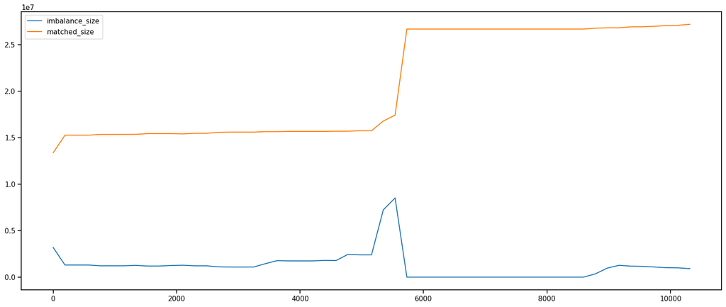

```python
df[(df.stock_id==0)&(df.date_id==0)][['imbalance_size','matched_size']].plot(figsize=(20,8))
```

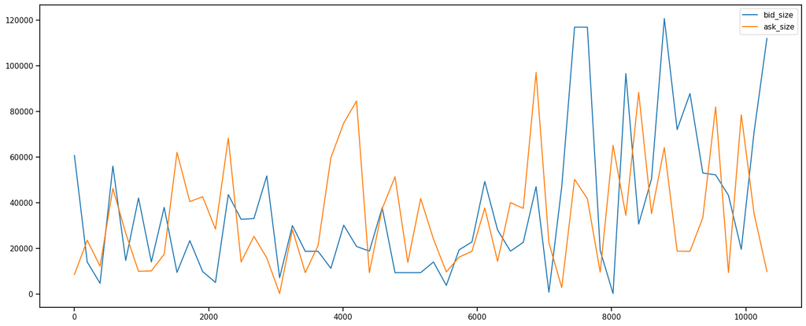

```python
df[(df.stock_id==0)&(df.date_id==0)][['bid_size','ask_size']].plot(figsize=(20,8))
```

```python
df[((df.far_price.isna())|(df.near_price.isna()))] #.describe()
```

|  | stock_id | date_id | seconds_in_bucket | imbalance_size | imbalance_buy_sell_flag | reference_price | matched_size | far_price | near_price | bid_price | bid_size | ask_price | ask_size | wap | target | time_id | row_id |
| --- | --- | --- | --- | --- | --- | --- | --- | --- | --- | --- | --- | --- | --- | --- | --- | --- | --- |
| 0 | 0 | 0 | 0 | 3180602.69 | 1 | 0.999812 | 13380276.64 | NaN | NaN | 0.999812 | 60651.50 | 1.000026 | 8493.03 | 1.000000 | -3.029704 | 0 | 0_0_0 |
| 191 | 0 | 0 | 10 | 1299772.70 | 1 | 1.000026 | 15261106.63 | NaN | NaN | 0.999812 | 13996.50 | 1.000026 | 23519.16 | 0.999892 | 0.389814 | 1 | 0_10_0 |
| 382 | 0 | 0 | 20 | 1299772.70 | 1 | 0.999919 | 15261106.63 | NaN | NaN | 0.999812 | 4665.50 | 0.999919 | 12131.60 | 0.999842 | 4.220009 | 2 | 0_20_0 |
| 573 | 0 | 0 | 30 | 1299772.70 | 1 | 1.000133 | 15261106.63 | NaN | NaN | 1.000026 | 55998.00 | 1.000133 | 46203.30 | 1.000085 | 5.450249 | 3 | 0_30_0 |
| 764 | 0 | 0 | 40 | 1218204.43 | 1 | 1.000455 | 15342674.90 | NaN | NaN | 1.000241 | 14655.95 | 1.000455 | 26610.45 | 1.000317 | 3.169775 | 4 | 0_40_0 |
| ... | ... | ... | ... | ... | ... | ... | ... | ... | ... | ... | ... | ... | ... | ... | ... | ... | ... |
| 5232179 | 199 | 480 | 250 | 7759010.62 | -1 | 1.000859 | 10099786.52 | NaN | NaN | 1.000859 | 106001.76 | 1.001177 | 42912.33 | 1.001085 | 11.379719 | 26425 | 480_250_199 |
| 5232379 | 199 | 480 | 260 | 7966297.16 | -1 | 1.001177 | 10074592.17 | NaN | NaN | 1.001177 | 91594.65 | 1.001494 | 63868.50 | 1.001364 | 9.360313 | 26426 | 480_260_199 |
| 5232579 | 199 | 480 | 270 | 8019205.31 | -1 | 1.001177 | 10102494.92 | NaN | NaN | 1.001177 | 96355.68 | 1.001494 | 67022.50 | 1.001364 | 10.010004 | 26427 | 480_270_199 |
| 5232779 | 199 | 480 | 280 | 139387.76 | 1 | 1.001494 | 19194853.72 | NaN | NaN | 1.001812 | 49186.45 | 1.002129 | 13002.72 | 1.002063 | 2.160072 | 26428 | 480_280_199 |
| 5232979 | 199 | 480 | 290 | 651305.54 | 1 | 1.002129 | 20255913.92 | NaN | NaN | 1.001812 | 85248.10 | 1.002129 | 40302.12 | 1.002027 | 0.669956 | 26429 | 480_290_199 |

2894342 rows × 17 columns

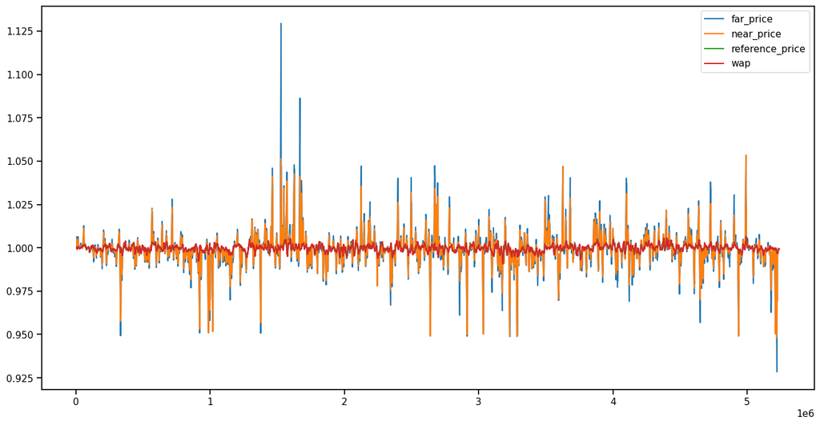

```python
df[(df.stock_id==198)&(~df.far_price.isna())&(~df.near_price.isna())][['far_price','near_price','reference_price','wap']].plot(figsize=(16,8))
```

```python
df.seconds_in_bucket.unique()
```

```
array([  0,  10,  20,  30,  40,  50,  60,  70,  80,  90, 100, 110, 120,
       130, 140, 150, 160, 170, 180, 190, 200, 210, 220, 230, 240, 250,
       260, 270, 280, 290, 300, 310, 320, 330, 340, 350, 360, 370, 380,
       390, 400, 410, 420, 430, 440, 450, 460, 470, 480, 490, 500, 510,
       520, 530, 540])
```

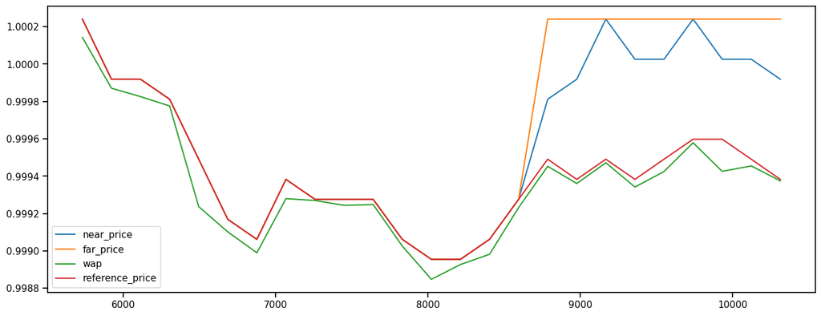

```python
df[(df.stock_id==0)&(df.date_id==0)&(~df.far_price.isna())][['near_price','far_price','wap','reference_price']].plot(figsize=(16,6))
```

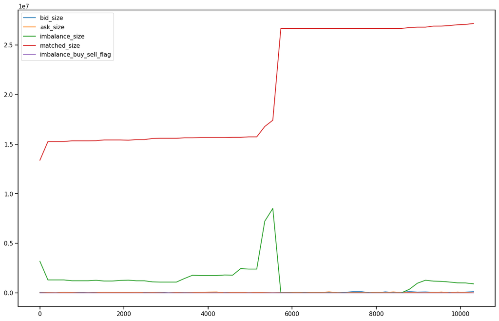

```python
df[(df.stock_id==0)&(df.date_id==0)][['bid_size','ask_size','imbalance_size','matched_size','imbalance_buy_sell_flag']].plot(figsize=(16,10))
```

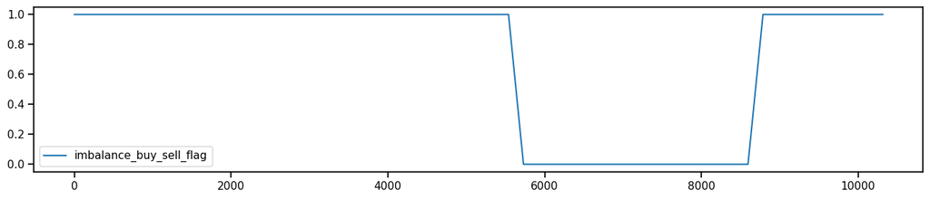

```python
df[(df.stock_id==0)&(df.date_id==0)][['imbalance_buy_sell_flag']].plot(figsize=(16,3))
```

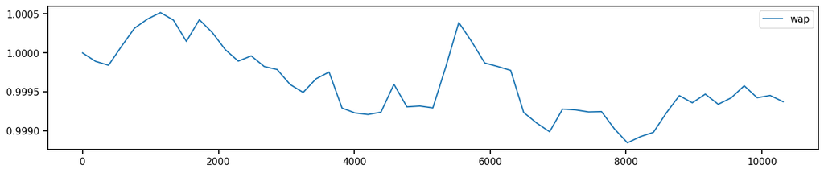

```python
df[(df.stock_id==0)&(df.date_id==0)][['wap']].plot(figsize=(16,3))
```

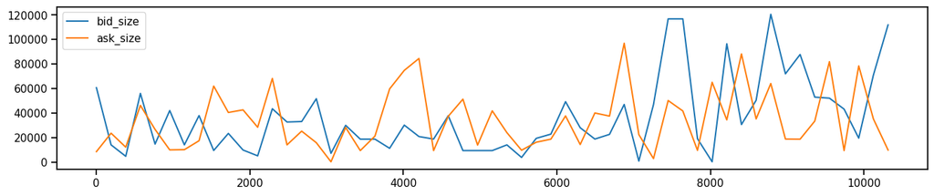

```python
df[(df.stock_id==0)&(df.date_id==0)][['bid_size','ask_size']].plot(figsize=(16,3))
```

# Finding weights

```python
%%time
def find_weights(df):
    """Find and return the weights of each stocks to index//['date_id','seconds_in_bucket']"""
    # Memo : 1. make sure there are 200 stocks in each batch; 2. Make sure no time series broken
    df['wap_chg6'] = df.wap.shift(-6)/df.wap
    df['index_wap_chg6'] = df.wap.shift(-6)/df.wap - df.target/10000
    return df

# Check and erase date_id contains wap NaN to avoid broken time series
print('Date_id having wap NaN : ', df.loc[df.wap.isna(), 'date_id'].unique())
df_w = df.loc[~df.date_id.isin(df.loc[df.wap.isna(), 'date_id'])] # erase full date
print('Shape: ',df_w.shape, ' / Any NaN in wap:',df_w.wap.isna().sum(), ' / Date_id contains NaN:', df_w.date_id.isin(df.loc[df.wap.isna(), 'date_id']).sum())
# Check if there are 200 stocks in 'date_id','seconds_in_bucket'
t200 = pd.DataFrame(data={'date_':df_w.groupby(['date_id','seconds_in_bucket'], group_keys=False).apply(lambda x : x['date_id'] if (x['stock_id'].count()!=200) else None  )})
# date_id having 200 stocks only
df_w = df_w.loc[~df_w.date_id.isin(t200.date_.dropna().unique().tolist())][['date_id','seconds_in_bucket','stock_id','wap','target']]
df_w = df_w.groupby(['date_id','stock_id'], group_keys=False).apply(find_weights)
df_w=df_w.dropna().sort_values(['date_id','seconds_in_bucket'])
# Wap index for Y train
df_wap_index = df_w.dropna().groupby(['date_id','seconds_in_bucket'], group_keys=False).apply(lambda x : x['index_wap_chg6'].mean())
# Wap for X train
df_wap = df_w.pivot_table(index=['date_id','seconds_in_bucket'],columns=['stock_id'], values=['wap_chg6'])

linreg = LinearRegression()
linreg.fit(df_wap, df_wap_index)
print('Linear model for calculate weights R2:', linreg.score(df_wap, df_wap_index), 'linreg.intercept_: ', linreg.intercept_)
weights = linreg.coef_.tolist()
weights = {int(k):v for k,v in enumerate(weights)}
```

```
Date_id having wap NaN :  [438 328  35 388]
Shape:  (5194420, 17)  / Any NaN in wap: 0  / Date_id contains NaN: 0
Linear model for calculate weights R2: 0.9999999943096245 linreg.intercept_:  -1.1744840922034427e-07
CPU times: user 51.1 s, sys: 1.72 s, total: 52.8 s
Wall time: 53.1 s
```

# Utilities Function

```python
# Numba TA Source: https://github.com/RomFR57/fastfinance/
# from math import fabs

@jit(nopython=True)
def sma(data, period):
    """
    Simple Moving Average
    :type data: np.ndarray
    :type period: int
    :rtype: np.ndarray
    """
    size = len(data)
    out = np.full(size, np.nan)
    for i in range(period - 1, size):
        window = data[i - period + 1:i + 1]
        out[i] = np.mean(window)
    return out

@jit(nopython=True)
def ema(data, period, smoothing=2.0):
    """
    Exponential Moving Average
    :type data: np.ndarray
    :type period: int
    :type smoothing: float
    :rtype: np.ndarray
    """
    size = len(data)
    weight = smoothing / (period + 1)
    out = np.full(size, np.nan)
    out[0] = data[0]
    for i in range(1, size):
        out[i] = (data[i] * weight) + (out[i - 1] * (1 - weight))
    out[:period - 1] = np.nan
    return out

@jit(nopython=True)
def rsi(data, period, smoothing=2.0, f_sma=True, f_clip=True, f_abs=True):
    """
    Relative Strengh Index
    :type data: np.ndarray
    :type period: int
    :type smoothing: float
    :type f_sma: bool
    :type f_clip: bool
    :type f_abs: bool
    :rtype: np.ndarray
    """
    size = len(data)
    delta = np.array([np.nan] * size)
    up = np.array([np.nan] * size)
    down = np.array([np.nan] * size)
    delta = np.diff(data)
    if f_clip:
        up, down = np.clip(delta, a_min=0, a_max=np.max(delta)), np.clip(delta, a_min=np.min(delta), a_max=0)
    else:
        up, down = delta.copy(), delta.copy()
        up[delta < 0] = 0.0
        down[delta > 0] = 0.0
    if f_abs:
        for i, x in enumerate(down):
            down[i] = fabs(x)
    else:
        down = np.abs(down)
    rs = sma(up, period) / sma(down, period) if f_sma else ema(up, period - 1, smoothing) / ema(
        down, period - 1, smoothing)
    out = np.full(size, np.nan)
    out[1:] = (100 - 100 / (1 + rs))
    return out

@jit(nopython=True)
def obv(c_close, c_volume):
    """
    On Balance Volume
    :type c_close: np.ndarray
    :type c_volume: np.ndarray
    :rtype: np.ndarray
    """
    size = len(c_close)
    out = np.full(size, np.nan)
    out[0] = 1
    for i in range(1, size):
        if c_close[i] > c_close[i - 1]:
            out[i] = out[i - 1] + c_volume[i]
        elif c_close[i] < c_close[i - 1]:
            out[i] = out[i - 1] - c_volume[i]
        else:
            out[i] = out[i - 1]
    return out

@jit(nopython=True)
def roc(data, period):
    """
    Rate Of Change
    :type data: np.ndarray
    :type period: int
    :rtype: np.ndarray
    """
    size = len(data)
    out = np.full(size, np.nan)
    for i in range(period - 1, size):
        p = data[i - period + 1]
        out[i] = ((data[i] - p) / p) * 100
    return out
```

```python
######################### For submission function ###########################
def pre_feat_(df):
    """Process 200 stocks and weighted indes wap in seconds_in_bucket, expect 200 rows of data per function call"""
    """>>['seconds_in_bucket'] """
    try:
        index_wap = (df.wap * df.stock_id.map(weights)).sum()/(df.stock_id.map(weights)).sum()
        df['index_wap'] =  index_wap   # check if 200 stocks included
    except Exception as e:
        index_wap = df.wap.sum()/df.wap.nunique()
        df['index_wap'] = index_wap
        print('>>>Error index_wap(pre_feat_): ', e)
    return df


def post_feat_(df, online):
    """Process by stock base within date. >>['stock_id','date_id'] """
    if online == False:
        n = 6
        try:
            df['wap60rtn_target'] = np.log(df.wap.shift(-6)/df.wap)  # label wap at next 60 seconds as log return target

            # quantile_10 = df['wap60rtn_target'].quantile(0.01)
            # quantile_90 = df['wap60rtn_target'].quantile(0.99)
            # df['wap60rtn_target'] = np.where(df['wap60rtn_target']>quantile_90, quantile_90, df['wap60rtn_target'])
            # df['wap60rtn_target'] = np.where(df['wap60rtn_target']<quantile_10, quantile_10, df['wap60rtn_target'])

        except Exception as e:
            df['wap60rtn_target'] = 0
            print('>>>post_feat_ wap60rtn_target: ',e)
    elif (online == True) & (df.seconds_in_bucket.unique()[0]<=50):  # live sample predict
        n = int(df.seconds_in_bucket.unique()[0]/10+1)
        df.wap = df.wap.fillna(0)
    else: n = 6  # live sample predict

    df['wap_chg'] = df.wap.pct_change(n)

    df['far_price'] = df['far_price'].fillna(df.reference_price)
    df['near_price'] = df['near_price'].fillna(df.wap)

    df['sector'] = df['stock_id'].map(sectors)
    df['sector'] = df['sector'].fillna(0)

    df['imb_size'] = df['imbalance_size']*df['imbalance_buy_sell_flag']
    imb_size_range = df['imb_size'].max()-df['imb_size'].min()
    df['imb_size'] = np.where(imb_size_range!=0, df['imb_size']/imb_size_range, 0)

    #df['matched_size']*df['reference_price'] # amount can be matched at current reference_price
    df['wap_in_bidask'] = ((df['wap']-df['bid_price']) / (df['ask_price']-df['bid_price']))

    df['bid_ask_midpt_diff'] = ((df['ask_price']+df['bid_price'])/2 - df['bid_price'])

    df['index_wap_chg'] = np.where(np.isnan(df['index_wap'].shift(n)), 0, df['index_wap']-df['index_wap'].shift(n) )

    df['bid_price_mod'] = np.where((df.ask_size+df.bid_size)!=0,df.bid_price*df.ask_size/(df.ask_size+df.bid_size),0)
    bid_price_mod_range = df['bid_price_mod'].max() -df['bid_price_mod'].min()
    df['bid_px_size_minmax'] = np.where(bid_price_mod_range!=0,df['bid_price_mod']/bid_price_mod_range,0)

    df['ask_price_mod'] = np.where((df.ask_size+df.bid_size)!=0,df.ask_price*df.bid_size/(df.ask_size+df.bid_size),0)
    ask_price_mod_range = df['ask_price_mod'].max()-df['ask_price_mod'].min()
    df['ask_px_size_minmax'] = np.where(ask_price_mod_range!=0,df['ask_price_mod']/ask_price_mod_range,0)

    df['wap_std'] = df.wap.rolling(n).std()
    wap_std_range = df['wap_std'].max() - df['wap_std'].min()
    df['Scaled_wap_std'] = np.where(wap_std_range!=0, df['wap_std']/wap_std_range, 0)

    df['Volatility'] = df['wap_std'] * np.sqrt(n)
    Volatility_mean = df['Volatility'].mean()
    Volatility_range = df['Volatility'].max()-df['Volatility'].min()
    df['Scaled_Volatility'] = np.where(Volatility_range!=0, (df['Volatility']-Volatility_mean)/Volatility_range, 0)

    df['Sharpe'] = df.wap.pct_change(n)/df.wap_std
    df['Sharpe'] = np.where(df['Sharpe'].isin([np.inf , -np.inf, np.nan]), 0, df['Sharpe'])

    df['imb_s1'] = (df.bid_size-df.ask_size)/(df.bid_size+df.ask_size)
    imb_s1_range = df['imb_s1'].max()-df['imb_s1'].min()
    df['imb_s1'] = np.where(imb_s1_range!=0, df['imb_s1']/imb_s1_range, 0)

    df['imb_s2'] = (df.imbalance_size-df.matched_size)/(df.matched_size+df.imbalance_size)
    imb_s2_range = df['imb_s2'].max()-df['imb_s2'].min()
    df['imb_s2'] = np.where(imb_s2_range!=0, df['imb_s2']/imb_s2_range, 0)



    ##############################  Rolling and Numba Parts  ###############################
    try:
        df['RSI'] = rsi(data=df.wap.to_numpy(), period=6)  # @ Numba
    except:
        df['RSI'] = 0

    df['OBV'] =  obv(df['reference_price'].to_numpy(), df['matched_size'].to_numpy())  # @ Numba
    OBV_range =  df['OBV'].max()-df['OBV'].min()
    df['OBV'] = np.where(OBV_range!=0, df['OBV']/OBV_range, 0)

    df['ROC'] = roc(data=df.wap.to_numpy(), period=n) # @ Numba
    ROC_mean = df['ROC'].mean()
    ROC_range = df['ROC'].max() - df['ROC'].min()
    df['Scaled_ROC'] = np.where(ROC_range!=0, (df['ROC']-ROC_mean)/ROC_range, 0)

    df['MA6_wap'] = df.wap - sma(data=df.wap.to_numpy(), period=n)    # @ Numba
    MA6_wap_range = df['MA6_wap'].max()-df['MA6_wap'].min()
    df['MA6_wap_minmax'] = np.where(MA6_wap_range!=0, df['MA6_wap']/MA6_wap_range, df.wap)

    df['EMA6_wap'] = df.wap- sma(data=df.wap.to_numpy(), period=n)   # @ Numba
    EMA6_wap_range = df['EMA6_wap'].max()-df['EMA6_wap'].min()
    df['EMA6_wap_minmax'] = np.where(EMA6_wap_range!=0, df['EMA6_wap']/EMA6_wap_range, df.wap)

    df['MA6_index_wap'] = df.index_wap - sma(data=df.index_wap.to_numpy(), period=n) # @ Numba
    MA6_index_wap_range = df['MA6_index_wap'].max() - df['MA6_index_wap'].min()
    df['MA6_index_wap'] = df['MA6_index_wap'] / MA6_index_wap_range

    df['EMA6_index_wap'] = df.index_wap - ema(data=df.index_wap.to_numpy(), period=n)  # @ Numba
    EMA6_index_wap_range = df['EMA6_index_wap'].max()-df['EMA6_index_wap'].min()
    df['EMA6_index_wap'] = df['EMA6_index_wap']/EMA6_index_wap_range

    if online == True: # live sample predict
        df['MA6_wap'] = df['MA6_wap'].fillna(df.wap)
        df['MA6_index_wap'] = df['MA6_index_wap'].fillna(df.index_wap)

        df['EMA6_wap'] = df['EMA6_wap'].fillna(df.wap)
        df['EMA6_index_wap'] = df['EMA6_index_wap'].fillna(df.index_wap)

        df['wap_std'] = df['wap_std'].fillna(0)
        df['Scaled_wap_std'] = df['Scaled_wap_std'].fillna(0)
        df['Scaled_wap_std'] = df['Scaled_wap_std'].fillna(0)
        df['Scaled_Volatility'] = df['Scaled_Volatility'].fillna(0)
        df['Volatility'] = df['Volatility'].fillna(0)
        df['RSI'] = df['RSI'].fillna(0)
        df['wap_chg'] = df['wap_chg'].fillna(0)

        df['far_price'] = df['far_price'].fillna(df.reference_price)
        df['near_price'] = df['near_price'].fillna(df.wap)
        df['far_price'] = df['far_price'].fillna(0)

        df.select_dtypes(['float','int']).replace([np.inf, -np.inf], np.nan, inplace=True)
        df.fillna(0, inplace=True)

    # Drop unwanted columns:   'stock_id','matched_size', 'date_id', 'seconds_in_bucket', 'ask_price','bid_price','ask_size','bid_size'
    cols = [c for c in df.columns if c not in['time_id','row_id','imbalance_buy_sell_flag',
                                'mat_imb_d','bid_price_mod','ask_price_mod'   ]]   #
    return df[cols]


def gen_final_result(df, online):
    """ ['date_id','seconds_in_bucket'] , ROBURST """
    #  np.exp(np.log(1.01)) = 1.01
    if online==False:   # Training session
        try:
            index_wap60rtn = (np.exp(df.pred_wap60rtn) * df.stock_id.map(weights)).sum() / (df.stock_id.map(weights)).sum()    # check if 200 stocks included
            df['pred_target'] = ((np.exp(df.pred_wap60rtn) -  index_wap60rtn )*10000).astype('float64')
        except Exception as e:
            index_wap60rtn = np.exp(df.pred_wap60rtn).sum() / df.pred_wap60rtn.nunique()
            df['pred_target'] = ((np.exp(df.pred_wap60rtn) - index_wap60rtn)*10000).astype('float64')
            print('>>>index_wap60 err(gen_final_result): ',e)

    else:  # live sample test session
        try:
            index_wap60rtn = (np.exp(df.pred_wap60rtn) * df.stock_id.map(weights)).sum() / (df.stock_id.map(weights)).sum()    # check if 200 stocks included
            df.loc[:,'pred_target'] = ((np.exp(df.pred_wap60rtn)-index_wap60rtn)*10000).astype('float64')
        except Exception as e:
            index_wap60rtn = np.exp(df.pred_wap60rtn).sum() / df.pred_wap60rtn.nunique()
            df['pred_target'] = ((np.exp(df.pred_wap60rtn) - index_wap60rtn)*10000).astype('float64')
            print('>>>index_wap60 err(gen_final_result) : ',e)

    return df['pred_target']
```

```python
def std_out(df):
    """ ['stock_id'] """
    std = df.wap.std()
    #df['std_pred'] =


    return df
```

## Enhance Pandas Performance

https://pandas.pydata.org/docs/user_guide/enhancingperf.html

## imb1 means (x-y)/(x+y), imb2 means min(x, y, z) / max(x, y, z), also make imb3 imba(norm(x), norm(y))

```python
# df['imbl_size1'] = (df['bid_size']-df['ask_size']) / (df['bid_size']+df['ask_size'])
# df['imbl_size2'] = (df['imbalance_size']-df['matched_size']) / (df['imbalance_size']+df['matched_size'])
#
```

# 1. Pre Featuring

```python
%%time
df_train = df.loc[~df.date_id.isin(df.loc[df.wap.isna(), 'date_id'])].groupby(['date_id','seconds_in_bucket'], group_keys=False).apply(pre_feat_)
df_train.shape

stock_corr = pd.DataFrame(data={'Corr':df_train.groupby('stock_id', group_keys=False).apply(lambda x: x['wap'].corr(x['index_wap'])).values})
bandwidth = estimate_bandwidth(stock_corr.values, quantile=0.095, n_samples=200)
ms = MeanShift(bandwidth=bandwidth, bin_seeding=True)
ms.fit(stock_corr.values)
labels = ms.labels_
sectors = {k:v for k,v in zip(stock_corr.index.tolist(), labels.tolist())}

# Wall time: 43.7 s
```

```
CPU times: user 46.4 s, sys: 2.41 s, total: 48.8 s
Wall time: 52.3 s
```

```python
# cluster_centers = ms.cluster_centers_
labels_unique = np.unique(labels)
labels_unique
# n_clusters_ = len(labels_unique)

# for k in range(n_clusters_):
#     my_members = labels == k
#     print("cluster {0}: {1}".format(k, X[my_members, 0]) )
# labels
```

```
array([0, 1, 2, 3, 4, 5, 6, 7, 8, 9])
```

# 2. Post Featuring

```python
%%time

df_train1 = df_train.groupby(['stock_id','date_id'], group_keys=False).apply(post_feat_, online=False)
print(df_train1.shape)
print(df_train1.isin([np.inf,-np.inf,np.nan]).sum())

# Wall time: 35min 58s, numba 32min 49s
```

```
(5194420, 41)
stock_id                   0
date_id                    0
seconds_in_bucket          0
imbalance_size             0
reference_price            0
matched_size               0
far_price                  0
near_price                 0
bid_price                  0
bid_size                   0
ask_price                  0
ask_size                   0
wap                        0
target                     0
index_wap                  0
wap60rtn_target       566664
wap_chg               566664
sector                     0
imb_size                   0
wap_in_bidask              0
bid_ask_midpt_diff         0
index_wap_chg              0
bid_px_size_minmax         0
ask_px_size_minmax         0
wap_std               472220
Scaled_wap_std        472220
Volatility            472220
Scaled_Volatility     472220
Sharpe                     0
imb_s1                     0
imb_s2                     0
RSI                   566783
OBV                        0
ROC                   472220
Scaled_ROC            472220
MA6_wap               472220
MA6_wap_minmax        472220
EMA6_wap              472220
EMA6_wap_minmax       472220
MA6_index_wap         472220
EMA6_index_wap        472220
dtype: int64
CPU times: user 32min 23s, sys: 29.2 s, total: 32min 52s
Wall time: 38min 22s
```

```python
df_train1.loc[df_train1.stock_id==2][['wap','wap60rtn_target','Scaled_ROC','Sharpe','RSI','Scaled_Volatility',
                                      'Scaled_wap_std','MA6_wap','MA6_wap_minmax','MA6_index_wap']].head(8)
```

|  | wap | wap60rtn_target | Scaled_ROC | Sharpe | RSI | Scaled_Volatility | Scaled_wap_std | MA6_wap | MA6_wap_minmax | MA6_index_wap |
| --- | --- | --- | --- | --- | --- | --- | --- | --- | --- | --- |
| 2 | 1.000000 | -0.000019 | NaN | 0.000000 | NaN | NaN | NaN | NaN | NaN | NaN |
| 193 | 1.000290 | -0.000257 | NaN | 0.000000 | NaN | NaN | NaN | NaN | NaN | NaN |
| 384 | 0.999857 | -0.000754 | NaN | 0.000000 | NaN | NaN | NaN | NaN | NaN | NaN |
| 575 | 0.999870 | -0.000785 | NaN | 0.000000 | NaN | NaN | NaN | NaN | NaN | NaN |
| 766 | 0.999397 | -0.000400 | NaN | 0.000000 | NaN | NaN | NaN | NaN | NaN | NaN |
| 957 | 1.000896 | -0.001349 | 0.248535 | 0.000000 | NaN | 0.138381 | 0.814716 | 0.000844 | 0.430856 | 0.000213 |
| 1148 | 0.999981 | 0.000306 | -0.102108 | -0.037639 | 49.737786 | 0.139106 | 0.815441 | -0.000068 | -0.034445 | 0.000224 |
| 1339 | 1.000033 | 0.000254 | 0.039014 | -0.523351 | 46.203840 | 0.116689 | 0.793024 | 0.000027 | 0.013948 | 0.000171 |

```python
# %%time
# Test live
# df_live = df_train.groupby(['stock_id','date_id'], group_keys=False).apply(post_feat_, online=True)
# print(df_live.shape)
# print(df_live.isin([np.inf,-np.inf,np.nan]).sum())

# Wall time: 37min 57s
```

```python
np.exp(-0.000257)
```

```python
1.000033/1.000290
```

```python
df_train1[(df_train1.stock_id==50)&(df_train1.date_id==100)][['wap']].plot(figsize=(16,3))
```

```python
df_train1[(df_train1.stock_id==20)&(df_train1.date_id==10)][['OBV']].plot(figsize=(16,3))
```

```python
df_train1.drop('target',axis=1).select_dtypes(include=['int', 'float']).corr()[['wap60rtn_target']].abs().sort_values(by='wap60rtn_target', ascending=False)
```

```python
df_train1.drop('target',axis=1).loc[(df_train1.sector==1)].select_dtypes(include=['int', 'float']).corr()[['wap60rtn_target']].abs().sort_values(by='wap60rtn_target', ascending=False)
```

```python
%%time
```

```python
df_train1.loc[df_train1.sector=='0'].drop('target',axis=1).select_dtypes(include=['int', 'float']).corr()[['wap60rtn_target']].abs().sort_values(by='wap60rtn_target', ascending=False)
```

```python
df_train1.drop('target',axis=1).select_dtypes(include=['int', 'float']).corr()[['wap60rtn_target']].abs().sort_values(by='wap60rtn_target', ascending=False)
```

# Feature Data Cleaning

```python
df_train1.drop('target',axis=1).hist(bins=50, figsize=(16,16))
plt.show()
```

```python
#df_train1.select_dtypes(['float','int']).fillna(0, inplace=True)
```

```python
%%time
df_train1 = df_train1.dropna()
df_train1.sector = df_train1.sector.astype('category')
print(df_train1.shape)
print(df_train1.isin([np.nan, np.inf, -np.inf]).sum())
```

```
(4060975, 41)
stock_id              0
date_id               0
seconds_in_bucket     0
imbalance_size        0
reference_price       0
matched_size          0
far_price             0
near_price            0
bid_price             0
bid_size              0
ask_price             0
ask_size              0
wap                   0
target                0
index_wap             0
wap60rtn_target       0
wap_chg               0
sector                0
imb_size              0
wap_in_bidask         0
bid_ask_midpt_diff    0
index_wap_chg         0
bid_px_size_minmax    0
ask_px_size_minmax    0
wap_std               0
Scaled_wap_std        0
Volatility            0
Scaled_Volatility     0
Sharpe                0
imb_s1                0
imb_s2                0
RSI                   0
OBV                   0
ROC                   0
Scaled_ROC            0
MA6_wap               0
MA6_wap_minmax        0
EMA6_wap              0
EMA6_wap_minmax       0
MA6_index_wap         0
EMA6_index_wap        0
dtype: int64
CPU times: user 16.5 s, sys: 828 ms, total: 17.3 s
Wall time: 17.8 s
```

# Fold Size Selection

```python
allodddays = df_train1.loc[df_train1.date_id % 2 == 1, 'date_id'].unique().tolist() #[120:]
allevendays = df_train1.loc[df_train1.date_id % 2 == 0, 'date_id'].unique().tolist()
```

```python
x_train = df_train1.loc[df_train1.date_id.isin(allevendays+allodddays[185:]) ].drop(columns=['wap60rtn_target','target','date_id','seconds_in_bucket','stock_id']).copy()    # put Outlier in training model
y_train = df_train1.loc[df_train1.date_id.isin(allevendays+allodddays[185:])][['wap60rtn_target']].copy()

# x_train = df_train1.loc[df_train1.date_id.isin(allevendays) ].drop(columns=['wap60rtn_target','target','date_id','seconds_in_bucket','stock_id']).copy()    # put Outlier in training model
# y_train = df_train1.loc[df_train1.date_id.isin(allevendays)][['wap60rtn_target']].copy()

# x_train = df_train1.drop(columns=['wap60rtn_target','target','date_id','seconds_in_bucket','stock_id']).copy()    # put Outlier in training model
# y_train = df_train1[['wap60rtn_target']].copy()

x_train.columns
```

```
Index(['imbalance_size', 'reference_price', 'matched_size', 'far_price',
       'near_price', 'bid_price', 'bid_size', 'ask_price', 'ask_size', 'wap',
       'index_wap', 'wap_chg', 'sector', 'imb_size', 'wap_in_bidask',
       'bid_ask_midpt_diff', 'index_wap_chg', 'bid_px_size_minmax',
       'ask_px_size_minmax', 'wap_std', 'Scaled_wap_std', 'Volatility',
       'Scaled_Volatility', 'Sharpe', 'imb_s1', 'imb_s2', 'RSI', 'OBV', 'ROC',
       'Scaled_ROC', 'MA6_wap', 'MA6_wap_minmax', 'EMA6_wap',
       'EMA6_wap_minmax', 'MA6_index_wap', 'EMA6_index_wap'],
      dtype='object')
```

```python
x_train.shape
```

[output not shown]

```python
x_train.info()
```

[output not shown]

[output cut: 28 more lines]

```python
df_train1.info()
```

```
<class 'pandas.core.frame.DataFrame'>
Index: 4060975 entries, 1146 to 5236779
Data columns (total 41 columns):
 #   Column              Dtype
---  ------              -----
 0   stock_id            int64
 1   date_id             int64
 2   seconds_in_bucket   int64
 3   imbalance_size      float64
 4   reference_price     float64
 5   matched_size        float64
 6   far_price           float64
 7   near_price          float64
 8   bid_price           float64
 9   bid_size            float64
```

[output cut: 33 more lines]

# Baseline: HGBR Model

```python
%%time

HGBRegressor = HistGradientBoostingRegressor(loss='absolute_error',
                                             categorical_features=['sector'],
                                             learning_rate=0.099,
                                             max_bins=203,
                                             max_leaf_nodes=2626,  # None: LONG hours
                                             l2_regularization=0,
                                             max_depth=None,
                                             max_iter=786,
                                             min_samples_leaf=51,
                                             random_state=0)
# {'learning_rate': 0.09900212779230882, 'max_bins': 203, 'max_leaf_nodes': 2626, 'max_iter': 786, 'max_depth': 51}
# Pred wap60rtn 3std outlier filtered, Best HGBR MAE: 0.0004653629509560629
```

```
CPU times: user 23 µs, sys: 0 ns, total: 23 µs
Wall time: 26.9 µs
```

```python
%%time
HGBRegressor.fit( x_train,  y_train.values.ravel() )

# R2 score
r2_ = HGBRegressor.score( x_train,  y_train.values.ravel() )
print(f"75fold R-square: {r2_:.6f}")

pred_ = HGBRegressor.predict( x_train )
mae_ = mean_absolute_error( y_train  , pred_ )
print(f"MAE : {mae_:.8f}")

# 17min 47s Predict wap60rtn 5%,95% Quantile outlier filtered, R-square: 0.557490 , MAE: 0.00043834
```

[output not shown]

```python
result = df_train1.copy()
result['pred_wap60rtn'] = HGBRegressor.predict(df_train1.drop(columns=['wap60rtn_target','target','date_id','seconds_in_bucket','stock_id'])  )
result['pred_target']= result.groupby(['date_id','seconds_in_bucket'], group_keys=False).apply(gen_final_result, online=False)
print('Final MAE: ', mean_absolute_error( result['pred_target'] , result['target'] ) )

# Pred wap60rtn 3std outlier filtered, Final MAE:  4.833563147271924
# Pred wap60rtn 5%,95% Quantile outlier filtered, Final MAE:  4.672464242415569
```

[output not shown]

# Model 2 : LightGBM Linear Model

```python
%%time
# categoricals=['sector']
LGB = lgb.LGBMRegressor(learning_rate=0.0798854575290318,
                        objective='mean_absolute_error',
                        n_estimators=900,
                        max_depth=80,
                        num_leaves=4095, # 1000
                        subsample=0.7106089792072736,  # 'subsample': 0.6693727032634107
                        colsample_bytree=0.8595558481476023, # OK
                        min_data_in_leaf=84, # <------- 'min_data_in_leaf': 83
                       )
#Best hyperparameters: {'learning_rate': 0.0798854575290318, 'max_depth': 80, 'num_leaves': 4095,
# 'subsample': 0.7106089792072736, 'colsample_bytree': 0.8595558481476023, 'min_data_in_leaf': 84}
```

```
CPU times: user 30 µs, sys: 5 µs, total: 35 µs
Wall time: 38.9 µs
```

```python
%%time
LGB.fit( x_train,  y_train ) # , categorical_feature='auto'

pred_ = LGB.predict(  x_train )
print('LGBM R2: ', r2_score( pred_ ,  y_train ) )
print('LGBM MAE: ', mean_absolute_error( pred_ ,  y_train ) )
# Pred wap60rtn 3std outlier filtered, 9 mins , R2; -0.5901930384049854  ;  LGBM MAE:  0.0004945676002128726
# Wall time: 10min 36s Pred wap60rtn 5%,95% Quantile outlier filtered, R2:  -0.9355787326710743, MAE:  0.0005053147306888465
# No Outlier filter, numba, even day fold (OBV, RSI, new),LGBM R2:  -0.40373983295146365,LGBM MAE:  0.00045107186547189764
```

```
[LightGBM] [Warning] min_data_in_leaf is set=84, min_child_samples=20 will be ignored. Current value: min_data_in_leaf=84
[LightGBM] [Warning] min_data_in_leaf is set=84, min_child_samples=20 will be ignored. Current value: min_data_in_leaf=84
[LightGBM] [Info] Auto-choosing row-wise multi-threading, the overhead of testing was 0.072312 seconds.
You can set `force_row_wise=true` to remove the overhead.
And if memory is not enough, you can set `force_col_wise=true`.
[LightGBM] [Info] Total Bins 8935
[LightGBM] [Info] Number of data points in the train set: 2490250, number of used features: 36
[LightGBM] [Info] Start training from score 0.000004
[LightGBM] [Warning] min_data_in_leaf is set=84, min_child_samples=20 will be ignored. Current value: min_data_in_leaf=84
LGBM R2:  -0.05618571351375623
LGBM MAE:  0.00036734950767473905
CPU times: user 48min 2s, sys: 1min 8s, total: 49min 11s
Wall time: 14min 14s
```

```python
result = df_train1.copy()
result['pred_wap60rtn'] = LGB.predict(df_train1.drop(columns=['wap60rtn_target','target','date_id','seconds_in_bucket','stock_id'])  )
result['pred_target']= result.groupby(['date_id','seconds_in_bucket'], group_keys=False).apply(gen_final_result, online=False)
print('Final MAE: ', mean_absolute_error( result['pred_target'] , result['target'] ) )

# Pred wap60rtn 3std outlier filtered, Final MAE:  4.886221224917565
# Pred wap60rtn 5%,95% Quantile outlier filtered, MAE:  5.19650890305619
# No Outlier filter, numba, even day fold (OBV, RSI, new), Final MAE:  5.185644823849621
```

```
[LightGBM] [Warning] min_data_in_leaf is set=84, min_child_samples=20 will be ignored. Current value: min_data_in_leaf=84
Final MAE:  4.631843082129342
```

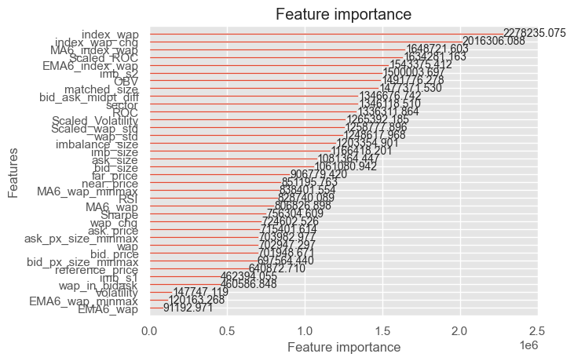

```python
lgb.plot_importance(LGB, importance_type="gain")
```

# StackingRegressor

```python
# %%time

# from sklearn.ensemble import StackingRegressor
# from sklearn.linear_model import RidgeCV

# estimators = [
#     ("HGBRegressor", HGBRegressor),
#     ("LGBM", LGB),
# ]

# SRG = StackingRegressor(estimators=estimators, final_estimator=RidgeCV())  # alpha=linreg.intercept_

# SRG.fit( x_train,  y_train.values.ravel() )
# pred_stack = SRG.predict( x_train )
# print('StackingRegressor MAE: ', mean_absolute_error( pred_stack, y_train.values.ravel() ) )

#  pred wap, 1h 32min 10s ;  StackingRegressor MAE:  0.00041908162089990063
```

```python
# result = df_train1
# result['pred_wap60rtn'] = pred_stack
# result['pred_target']= result.groupby(['date_id','seconds_in_bucket'], group_keys=False).apply(gen_final_result, online=False)
# print('Final MAE: ', mean_absolute_error( result['pred_target'] , result['target'] ) )

# pred wap, Final MAE:  4.849009142605059
```

# VotingRegressor

```python
%%time
from sklearn.ensemble import VotingRegressor

VR = VotingRegressor([('HGBRegressor', HGBRegressor ),
                      ('LightGBM', LGB)])

VR.fit( x_train,  y_train.values.ravel() )

print('VotingRegressor R2 Score: ', VR.score( x_train,  y_train.values.ravel() )   )

pred_vr = VR.predict( x_train )
print('VotingRegressor MAE: ', mean_absolute_error(pred_vr, y_train.values.ravel() ) )

# pred wap, 25min 47s   R2 Score: 0.5266466304744698   ;  VotingRegressor MAE: 0.00048481785265064
# Wall time: 1h 55min 48s , Outlier filered with quantile, R2 Score:  0.550465917948346, MAE:  0.0004256825581131216
# Wall time: 24min 9s , Outlier filered with 3 std, R2 Score:  0.5187338996768383, MAE:  0.0004902908136712132
# Pred wap60rtn 5%,95% Quantile outlier filtered,R2 Score:  0.51963376378680492, MAE:  0.0004695571311482985
# 5,95% Quantile, 250 days fold, R2 Score:  0.5750040669220189, MAE:  0.00040651107199694326
# 4,96% Quantile, 250 days fold, R2 Score:  0.5533870891664674, MAE:  0.00042359857053735805
# 3,97% Quantile, 250 days fold, R2 Score:  0.5742511975251912, MAE:  0.00041358639339396396
# 3,97% Q, numba, even day + 120 fold (OBV, RSI), R2 Score:  0.436262346243254, MAE:  0.0005126068440152154
# 2,98% Quantile, even day fold (OBV, RSI), R2 Score:  0.5787185102035146, MAE:  0.0004354365533700043
# 2,98, Qtile , numba, even day fold (OBV, RSI), R2 Score:  0.4929301636615747, MAE:  0.0004885605693329163
# 2,98, Qtile , numba, even+120odd add minmax, R2 Score:  0.4230738627488124, MAE:  0.0005248541103862546
# 1,99% Quantile, 250 days fold, R2 Score:  0.5512368160153982, MAE:  0.00043380997593460543
# 1,99% Quantile, even day fold (OBV, RSI), R2 Score:  0.5564688270327112, MAE:  0.0004546597017835438
# 1,99% Qtile , numba, even day fold (OBV, RSI),R2 Score:  0.4529151565610725, MAE:  0.0005195549868899612
# 1,99% Qtile , numba, even+120odd fold (OBV, RSI), R2 Score:  0.451788063643048, MAE:  0.0005057949971053711
# 1,99% Qtile , numba, full dataset, R2 Score:  0.38914086783240065, MAE:  0.0005539969990318116
# 1,99% Qtile , numba, even+lastest100odd, R2 Score:  0.43063908378218474, MAE:  0.0005243234010732818
# 1,99% Quantile, numba, all fold (OBV, RSI, new), R2 Score:  0.3976775383455241, MAE:  0.0005515797472715651
# 1,99% Quantile, numba, even day fold (OBV, RSI, new), R2 Score:  0.5188788817800712, MAE:  0.00046918433929131194
# 0.5,99.5% Qtl, even day fold (OBV, RSI), R2 Score:  0.49522659264388, MAE:  0.0004897049486935706
# No Outlier filter, even day fold (OBV, RSI), R2 Score:  0.5609443404179819, MAE:  0.0004518952507236412
# No Outlier filter, numba, even day fold (OBV, RSI), R2 Score:  0.44674539546701086, MAE:  0.0005272633537696989
# No Outlier filter, numba, even day fold (OBV, RSI, new), R2 Score:  0.5783960586509512, MAE:  0.0004364065400187279

# No Outlier, numba, all even + [200:]odd fold, (OBV, RSI, new), R2 Score:  0.5426727386783524, MAE:  0.00045768350649975453
# No Outlier, numba, all even + [190:]odd fold, (OBV, RSI, new), R2 Score:  0.5545493486140802, MAE:  0.00044714956465621185 <-@@@@@@
# No Outlier, numba, all even + [185:]odd fold, (OBV, RSI, new), R2 Score:  0.5446671741275978, MAE:  0.0004555077088068594
# No Outlier, numba, all even + [180:]odd fold, (OBV, RSI, new), R2 Score:  0.5428936331997326, MAE:  0.00045590485643363937
# No Outlier, numba, all even + [170:]odd fold, (OBV, RSI, new), R2 Score:  0.5365235767907344, MAE:  0.00045997664726193975
# No Outlier, numba, all even + [160:]odd fold, (OBV, RSI, new), R2 Score:  0.5211119898039773, MAE:  0.00046909792273136665
# No Outlier, numba, all even + [140:]odd fold, (OBV, RSI, new), R2 Score:  0.5221749237891606, MAE:  0.0004730512721269879
```

```
[LightGBM] [Warning] min_data_in_leaf is set=84, min_child_samples=20 will be ignored. Current value: min_data_in_leaf=84
[LightGBM] [Warning] min_data_in_leaf is set=84, min_child_samples=20 will be ignored. Current value: min_data_in_leaf=84
[LightGBM] [Info] Auto-choosing row-wise multi-threading, the overhead of testing was 0.050460 seconds.
You can set `force_row_wise=true` to remove the overhead.
And if memory is not enough, you can set `force_col_wise=true`.
[LightGBM] [Info] Total Bins 8935
[LightGBM] [Info] Number of data points in the train set: 2490250, number of used features: 36
[LightGBM] [Info] Start training from score 0.000004
[LightGBM] [Warning] min_data_in_leaf is set=84, min_child_samples=20 will be ignored. Current value: min_data_in_leaf=84
VotingRegressor R2 Score:  0.5987989846429734
[LightGBM] [Warning] min_data_in_leaf is set=84, min_child_samples=20 will be ignored. Current value: min_data_in_leaf=84
VotingRegressor MAE:  0.00040563293856038415
CPU times: user 1h 44min 29s, sys: 3min 35s, total: 1h 48min 5s
Wall time: 29min 36s
```

```python
%%time
result = df_train1.copy()
result['pred_wap60rtn'] = VR.predict(df_train1.drop(columns=['wap60rtn_target','target','date_id','seconds_in_bucket','stock_id'])  )
result['pred_target']= result.groupby(['date_id','seconds_in_bucket'], group_keys=False).apply(gen_final_result, online=False)
print('-'*20,' Total rows processed: ',len(result),', Total days processed: ',result.date_id.nunique(),'-'*20)
print('Final MAE: ', mean_absolute_error( result['pred_target'] , result['target'] ) )
# pred wap , Final MAE:  5.1924307589884195
# pred wapRTN ,  Final MAE:  4.778892916955702
# Outlier filered with 10,90 quantile, MAE:  4.901471409509798
# Outlier filered with 3 std, MAE:  4.8296852060876185
# Pred wap60rtn 5%,95% Quantile outlier filtered, MAE:  4.90067457701522
# 5,95% Quantile, 250 days fold, Final MAE:  5.139248110303604
# 4,96% Quantile, 250 days fold, Final MAE:  5.208786800546294
# 3,97% Quantile, 250 days fold, Final MAE:  5.1201067908538604
# 3,97% Q, numba, even day + 120 fold (OBV, RSI), Final MAE:  5.487712548276694
# 2,98% Quantile, even day fold (OBV, RSI), Final MAE:  5.094466884906214
# 2,98, Qtile , numba, even day fold (OBV, RSI), Final MAE:  5.510828924412472
# 2,98, Qtile , numba, even+120odd add minmax, Final MAE:  5.5264187666849205
# 1,99% Quantile, 250 days fold, Final MAE:  5.1691126943705346
# 1,99% Quantile, even day fold (OBV, RSI), Final MAE:  5.155832935420897
# 1,99% Qtile , numba, even day fold (OBV, RSI), Final MAE:  5.621461740075067
# 1,99% Qtile , numba, even+lastest100odd, Final MAE:  5.530278662690379
# 1,99% Qtile , numba, even+120odd fold (OBV, RSI), Final MAE:  5.405043749681622
# 1,99% Qtile , numba, full dataset, Final MAE:  5.522953983024296
# 1,99% Quantile, numba, all fold (OBV, RSI, new), Final MAE:  5.478836573281165
# 1,99% Quantile, numba, even day fold (OBV, RSI, new), Final MAE:  5.414751855813832
# 0.5,99.5% Qtl, even day fold (OBV, RSI), Final MAE:  5.486061351051006
# No Outlier filter, even day fold (OBV, RSI), Final MAE:  5.1260909008218505
# No Outlier filter, numba, even day fold (OBV, RSI), Final MAE:  5.525077970001924

# No Outlier, numba, even day fold (OBV, RSI, new), Final MAE:  5.0981103325459145
# No Outlier, numba, all even + [200:]odd fold, (OBV, RSI, new), Final MAE:  5.113597821535562
# No Outlier, numba, all even + [190:]odd fold, (OBV, RSI, new), Final MAE:  5.028879729806505 @@@@@-----
# No Outlier, numba, all even + [185:]odd fold, (OBV, RSI, new), Final MAE:  5.0641306351005335
# No Outlier, numba, all even + [180:]odd fold, (OBV, RSI, new), Final MAE:  5.050527636088444
# No Outlier, numba, all even + [170:]odd fold, (OBV, RSI, new), Final MAE:  5.05123624940127
# No Outlier, numba, all even + [160:]odd fold, (OBV, RSI, new), Final MAE:  5.075952798518856
# No Outlier, numba, all even + [140:]odd fold, (OBV, RSI, new), Final MAE:  5.051128389776271
```

[output not shown]

```python
x_train.info()
```

```
<class 'pandas.core.frame.DataFrame'>
Index: 2490250 entries, 1146 to 5236779
Data columns (total 36 columns):
 #   Column              Dtype
---  ------              -----
 0   imbalance_size      float64
 1   reference_price     float64
 2   matched_size        float64
 3   far_price           float64
 4   near_price          float64
 5   bid_price           float64
 6   bid_size            float64
 7   ask_price           float64
 8   ask_size            float64
 9   wap                 float64
```

[output cut: 28 more lines]

```python
# %%time
# def longshot(listOfPrices, listOfSharpe):
#     """
#     https://github.com/gotoConversion/goto_conversion/blob/main/goto_conversion/__init__.py
#     """
#     listOfSe = [x**0.5 for x in listOfSharpe] #compute standard errors assuming standard deviation is same for all stocks
#     step = sum(listOfPrices)/sum(listOfSe)
#     outputListOfPrices = [x - (y*step) for x,y in zip(listOfPrices, listOfSe)]
#     return outputListOfPrices

# result['pred_wap60rtn'] = longshot(result['pred_wap60rtn'], result['Sharpe'].to_numpy())
# result['pred_target2']= result.groupby(['date_id','seconds_in_bucket'], group_keys=False).apply(gen_final_result, online=False)
# print('Final MAE: ', mean_absolute_error( result['pred_target2'] , result['target'] ) )
```

# Analysis on Predict and Target

```python
print(f"target variance: +{result['target'].mean()+3*result['target'].std()} to {result['target'].mean()-3*result['target'].std()}")
print(f"pred_target variance: +{result['pred_target'].mean()+3*result['pred_target'].std()} to {result['pred_target'].mean()-3*result['pred_target'].std()}")
result[['pred_target','target']].describe()
```

```
target variance: +28.509435864188088 to -28.6378715456753
pred_target variance: +10.183110614658984 to -10.31018063929123
```

|  | pred_target | target |
| --- | --- | --- |
| count | 4.060975e+06 | 4.060975e+06 |
| mean | -6.353501e-02 | -6.421784e-02 |
| std | 3.415549e+00 | 9.524551e+00 |
| min | -4.279225e+01 | -3.852898e+02 |
| 25% | -1.908466e+00 | -4.590154e+00 |
| 50% | -6.540744e-02 | -6.973743e-02 |
| 75% | 1.768305e+00 | 4.409552e+00 |
| max | 4.679586e+01 | 2.571106e+02 |

[output not shown]

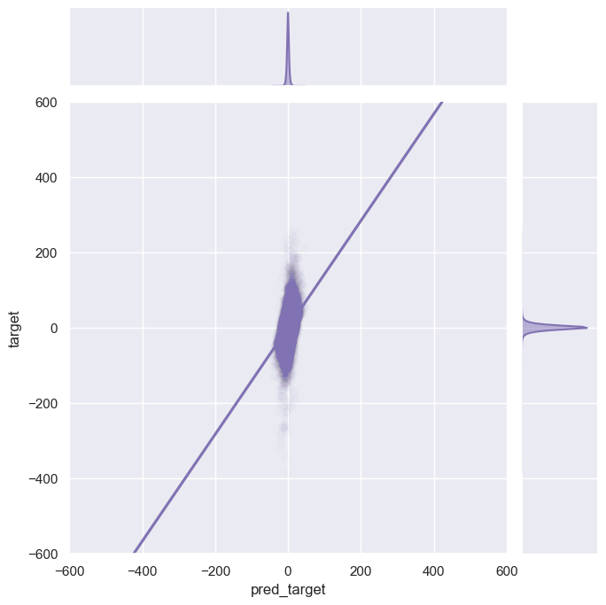

```python
%%time
sns.set_theme(style="darkgrid")
g = sns.jointplot(x="pred_target", y="target", data=result,
                  kind="reg", truncate=False,
                  xlim=(-600, 600), ylim=(-600, 600),
                  color="m", height=7, joint_kws={'scatter_kws':dict(alpha=0.01)} )
```

# corrs.mean() / corrs.std()

# Fine Tuning LGBM Using - Optuna

```python
import optuna

def objective(trial):
    params = {
        "objective": "regression_l1",
        "metric": "l1",
        "n_estimators": 1000,
        "verbosity": -1,
        "bagging_freq": 1,
        "learning_rate": trial.suggest_float("learning_rate", 0.05, 0.08, log=True),
        "max_depth": trial.suggest_int("max_depth", 80, 110),  # 92
        "num_leaves": trial.suggest_int("num_leaves", 2, 2**12),
        "subsample": trial.suggest_float("subsample", 0.6, 1.0),
        "colsample_bytree": trial.suggest_float("colsample_bytree", 0.7, 1.0),
        "min_data_in_leaf": trial.suggest_int("min_data_in_leaf", 80, 110),
    }

    model = lgb.LGBMRegressor(**params)
    model.fit( x_train,  y_train )
    predictions = model.predict( x_train )
    mae = mean_absolute_error( y_train , predictions)
    return mae
# Best hyperparameters: {'learning_rate': 0.08910970631950726, 'max_depth': 92, 'num_leaves': 1024,
#    'subsample': 0.7759941245600445, 'colsample_bytree': 0.8529712062001551, 'min_data_in_leaf': 90}
# Best MAE: 0.0005323607759726737
```

```python
%%time
study = optuna.create_study(direction='minimize')
study.optimize(objective, n_trials=30)
print('Best hyperparameters:', study.best_params)
print('Best MAE:', study.best_value)

# 5h 2min 26s
# Best hyperparameters: {'learning_rate': 0.08910970631950726, 'max_depth': 92, 'num_leaves': 1024, 'subsample': 0.7759941245600445, 'colsample_bytree': 0.8529712062001551, 'min_data_in_leaf': 90}
# Best MAE: 0.0005323607759726737
```

[output not shown]

[output cut: 11 more lines]

```
Best hyperparameters: {'learning_rate': 0.0798854575290318, 'max_depth': 80, 'num_leaves': 4095, 'subsample': 0.7106089792072736, 'colsample_bytree': 0.8595558481476023, 'min_data_in_leaf': 84}
Best MAE: 0.00035502154106043773
CPU times: user 23h 18min 4s, sys: 25min 13s, total: 23h 43min 18s
Wall time: 14h 45min 2s
```

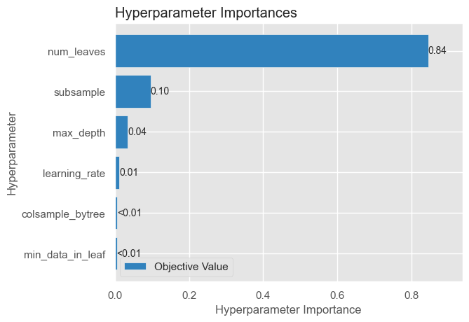

```python
optuna.visualization.matplotlib.plot_param_importances(study)
```

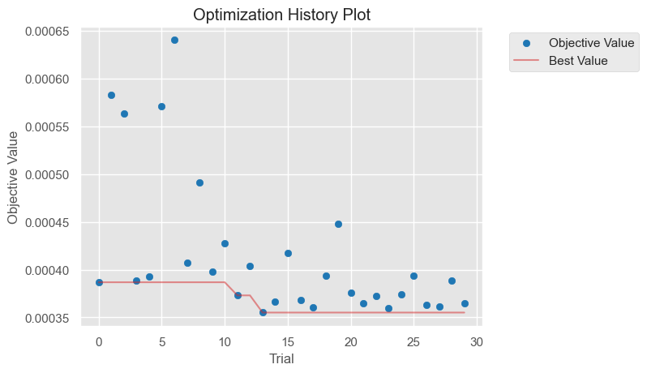

```python
optuna.visualization.matplotlib.plot_optimization_history(study)
```

[output not shown]

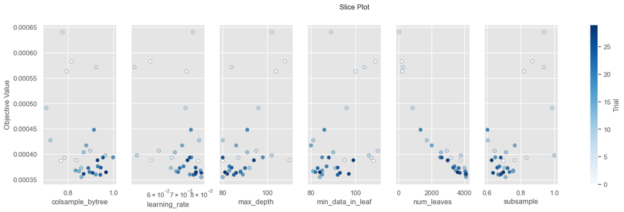

```python
optuna.visualization.matplotlib.plot_slice(study, params=['max_depth','min_data_in_leaf','num_leaves','learning_rate',"subsample","colsample_bytree"])
```

# Fine Tuning HGBR Using - Optuna

```python
import optuna

def objective(trial):
    params2 = {
        "loss" : 'absolute_error',
        "l2_regularization" : 0,
        #"max_depth" : "None",
        "random_state" : 0,
        "learning_rate": trial.suggest_float("learning_rate", 0.05, 0.1, log=True),
        "max_bins": trial.suggest_int("max_bins", 1, 255),  # 255
        "max_leaf_nodes": trial.suggest_int("max_leaf_nodes", 800, 3000), # =2000,  # None: LONG hours
        "max_iter": trial.suggest_int("max_iter", 300, 1000), #=786,
        "min_samples_leaf": trial.suggest_int("min_samples_leaf", 10, 200), # =51,
    }

    model2 = HistGradientBoostingRegressor(**params2,categorical_features=['sector'],)
    model2.fit( x_train,  y_train.values.ravel() )
    predictions2 = model2.predict( x_train )
    mae2 = mean_absolute_error( y_train.values.ravel() , predictions2)
    return mae2
```

```python
%%time
study2 = optuna.create_study(direction='minimize')
study2.optimize(objective, n_trials=30)
print('Best HGBR hyperparameters:', study2.best_params)
print('Best HGBR MAE:', study2.best_value)
```

```python
optuna.visualization.matplotlib.plot_param_importances(study2)
```

```python
optuna.visualization.matplotlib.plot_optimization_history(study2)
```

```python
optuna.visualization.matplotlib.plot_slice(study2, params=["learning_rate","max_bins","max_leaf_nodes","max_iter","min_samples_leaf"])
```

# Size Re-mapping

```python
import sys; print(sys.executable)
```

```
/Users/honcylee/.pyenv/versions/3.9.18/bin/python3.9
```

# Submission

```python
%time
import optiver2023
env = optiver2023.make_env()
iter_test = env.iter_test()
```

```
CPU times: user 3 µs, sys: 1e+03 ns, total: 4 µs
Wall time: 5.96 µs
```

[output not shown]

```python
count = 0
for (test, revealed_targets, sample_prediction) in tqdm(iter_test):
    unique_stocks = test.stock_id.nunique()

    if count == 0:
        display(test.head())
        display(revealed_targets.head())
        display(sample_prediction.head())

    count += 1
    sample_prediction['target'] = 0
    env.predict(sample_prediction)
```

[output not shown]

# Submission Scoring Error: Your notebook generated a submission file with incorrect format. Some examples causing this are: wrong number of rows or columns, empty values, an incorrect data type for a value, or invalid submission values from what is expected.